# 다변량자료분석 HW3

## 공분산행렬(Σ)

```r
sigma<-matrix(c(4,1,2,1,9,-3,2,-3,25),nrow=3)
sigma
```

```
##      [,1] [,2] [,3]
## [1,]    4    1    2
## [2,]    1    9   -3
## [3,]    2   -3   25
```

## 대각성분행렬(V<sup>-1/2</sup>)

```r
v_1_2<-diag(3)
for (i in 1:nrow(v_1_2)){
  v_1_2[i,i]<-(1/sigma[i,i])^(1/2)
}
v_1_2
```

```
##      [,1]      [,2] [,3]
## [1,]  0.5 0.0000000  0.0
## [2,]  0.0 0.3333333  0.0
## [3,]  0.0 0.0000000  0.2
```

## 상관계수행렬(ρ)

```r
low<-v_1_2%*%sigma%*%v_1_2
low
```

```
##           [,1]       [,2] [,3]
## [1,] 1.0000000  0.1666667  0.2
## [2,] 0.1666667  1.0000000 -0.2
## [3,] 0.2000000 -0.2000000  1.0
```

## 참고: cov2cor() 코드로도 가능

```r
x<-cov2cor(sigma)
x
```

```
##           [,1]       [,2] [,3]
## [1,] 1.0000000  0.1666667  0.2
## [2,] 0.1666667  1.0000000 -0.2
## [3,] 0.2000000 -0.2000000  1.0
```

```r
x==low
```

```
##      [,1] [,2] [,3]
## [1,] TRUE TRUE TRUE
## [2,] TRUE TRUE TRUE
## [3,] TRUE TRUE TRUE
```

–> 결과 값 같은 것 확인 가능!

### 문제2 : 평균벡터,공분산행렬, 상관계수행렬 구하기

# 데이터 정의

```r
x_1<-c(90,80,75,70,65)
x_2<-c(80,90,80,70,80)
x<-data.frame(x_1,x_2)
x
```

```
##   x_1 x_2
## 1  90  80
## 2  80  90
## 3  75  80
## 4  70  70
## 5  65  80
```

# 평균 벡터

```r
meanvector<-apply(x,2,mean)
meanvector
```

```
## x_1 x_2
##  76  80
```

# 공분산 행렬

```r
cov(x)
```

```
##      x_1 x_2
## x_1 92.5  25
## x_2 25.0  50
```

# 상관계수 행렬

```r
cor(x)
```

```
##           x_1       x_2
## x_1 1.0000000 0.3676073
## x_2 0.3676073 1.0000000
```

### 문제3 : Seatbelts 자료 요약 및 시각화, (가설을 세워)해석하기.

# 데이터 정의

```r
data(Seatbelts)
Seatbelts<-data.frame(Year=floor(time(Seatbelts)),Month=factor(cycle(Seatbelts),labels=month.abb), Seatbelts)
Seatbelts<-as.data.frame(Seatbelts)
```

# 데이터 요약

```r
head(Seatbelts)          #앞에서부터 6개의 행만 먼저 보여줌
```

```
##   Year Month DriversKilled drivers front rear   kms PetrolPrice VanKilled law
## 1 1969   Jan           107    1687   867  269  9059   0.1029718        12   0
## 2 1969   Feb            97    1508   825  265  7685   0.1023630         6   0
## 3 1969   Mar           102    1507   806  319  9963   0.1020625        12   0
## 4 1969   Apr            87    1385   814  407 10955   0.1008733         8   0
## 5 1969   May           119    1632   991  454 11823   0.1010197        10   0
## 6 1969   Jun           106    1511   945  427 12391   0.1005812        13   0
```

```r
dim(Seatbelts)           #데이터 행 , 열 개수
```

```
## [1] 192  10
```

```r
str(Seatbelts)           #각 열에 특징을 알려줌
```

```
## 'data.frame':    192 obs. of  10 variables:
##  $ Year         : Time-Series  from 1969 to 1985: 1969 1969 1969 1969 1969 ...
##  $ Month        : Factor w/ 12 levels "Jan","Feb","Mar",..: 1 2 3 4 5 6 7 8 9 10 ...
##  $ DriversKilled: num  107 97 102 87 119 106 110 106 107 134 ...
##  $ drivers      : num  1687 1508 1507 1385 1632 ...
##  $ front        : num  867 825 806 814 991 ...
##  $ rear         : num  269 265 319 407 454 427 522 536 405 437 ...
##  $ kms          : num  9059 7685 9963 10955 11823 ...
##  $ PetrolPrice  : num  0.103 0.102 0.102 0.101 0.101 ...
##  $ VanKilled    : num  12 6 12 8 10 13 11 6 10 16 ...
##  $ law          : num  0 0 0 0 0 0 0 0 0 0 ...
```

```r
summary(Seatbelts)       #변수들의 수치적 특성 요약
```

```
##       Year          Month    DriversKilled      drivers         front
##  Min.   :1969   Jan    :16   Min.   : 60.0   Min.   :1057   Min.   : 426.0
##  1st Qu.:1973   Feb    :16   1st Qu.:104.8   1st Qu.:1462   1st Qu.: 715.5
##  Median :1976   Mar    :16   Median :118.5   Median :1631   Median : 828.5
##  Mean   :1976   Apr    :16   Mean   :122.8   Mean   :1670   Mean   : 837.2
##  3rd Qu.:1980   May    :16   3rd Qu.:138.0   3rd Qu.:1851   3rd Qu.: 950.8
##  Max.   :1984   Jun    :16   Max.   :198.0   Max.   :2654   Max.   :1299.0
##                 (Other):96
##       rear            kms         PetrolPrice        VanKilled
##  Min.   :224.0   Min.   : 7685   Min.   :0.08118   Min.   : 2.000
##  1st Qu.:344.8   1st Qu.:12685   1st Qu.:0.09258   1st Qu.: 6.000
##  Median :401.5   Median :14987   Median :0.10448   Median : 8.000
##  Mean   :401.2   Mean   :14994   Mean   :0.10362   Mean   : 9.057
##  3rd Qu.:456.2   3rd Qu.:17203   3rd Qu.:0.11406   3rd Qu.:12.000
##  Max.   :646.0   Max.   :21626   Max.   :0.13303   Max.   :17.000
##
##       law
##  Min.   :0.0000
##  1st Qu.:0.0000
##  Median :0.0000
##  Mean   :0.1198
##  3rd Qu.:0.0000
##  Max.   :1.0000
##
```

# 데이터 구분 (1983년 2월기준)

```r
Seatbelts_1<-Seatbelts[1:169,]
Seatbelts_2<-Seatbelts[170:192,]
```

# 시각화

1.법의 제정여부와 운전자사망수

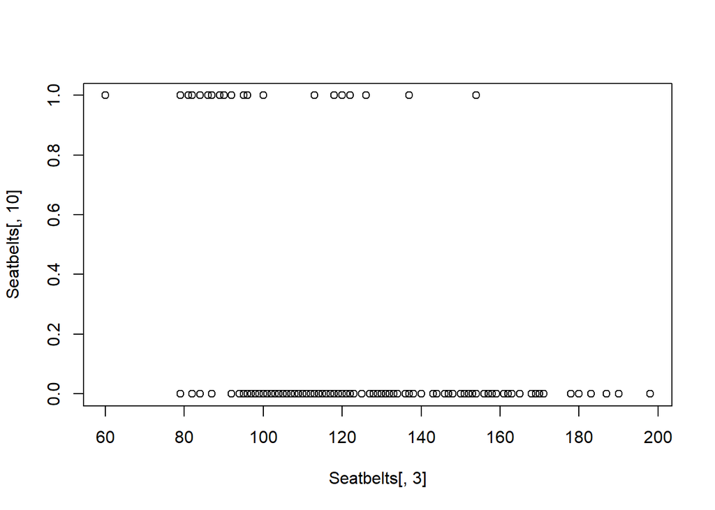

```r
plot(Seatbelts[,10]~Seatbelts[,3])
```

2.boxplot

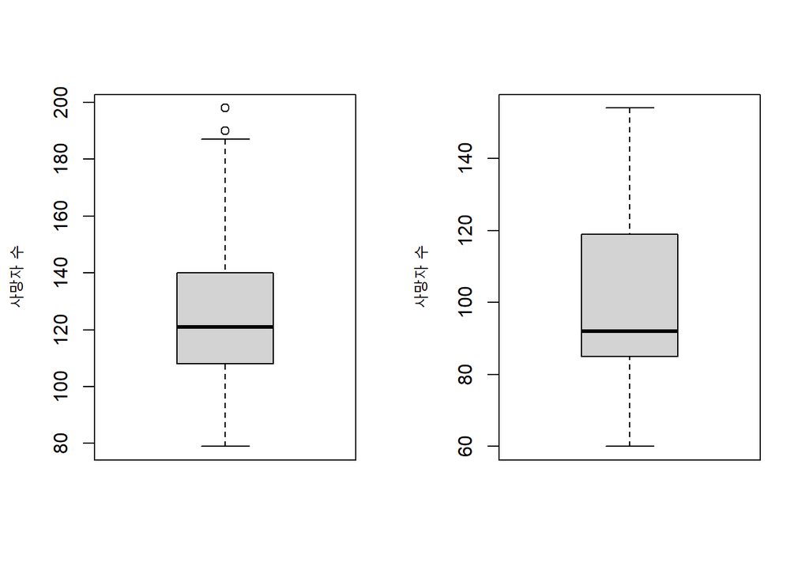

```r
par(mfrow=c(1,2))
boxplot(Seatbelts_1[,3],ylab="사망자 수")
boxplot(Seatbelts_2[,3],ylab="사망자 수")
```

```r
par(mfrow=c(1,1))  #원상복귀
```

# 가설설정

H<sub>0</sub> : 법이 제정되기 전 과 후의 운전자 사망자의 수가 차이가 없다.  
H<sub>1</sub> : 법이 제정되기 전 과 후의 운전자 사망자의 수가 차이가 있다.  
Set 유의수준(α) = 5 %

# 가설검정 (두 집단의 모평균 비교검정)

등분산 검정

```r
var.test(Seatbelts_1[,3],Seatbelts_2[,3])
```

```
##
##  F test to compare two variances
##
## data:  Seatbelts_1[, 3] and Seatbelts_2[, 3]
## F = 1.1912, num df = 168, denom df = 22, p-value = 0.6535
## alternative hypothesis: true ratio of variances is not equal to 1
## 95 percent confidence interval:
##  0.5794668 2.0916430
## sample estimates:
## ratio of variances
##           1.191211
```

p-value > α –> 등분산성 가정 가능!

## 두 집단의 모평균 비교 검정

```r
t.test(Seatbelts_1[,3],Seatbelts_2[,3],var.equal=TRUE)
```

```
##
##  Two Sample t-test
##
## data:  Seatbelts_1[, 3] and Seatbelts_2[, 3]
## t = 4.7942, df = 190, p-value = 3.288e-06
## alternative hypothesis: true difference in means is not equal to 0
## 95 percent confidence interval:
##  15.07239 36.14552
## sample estimates:
## mean of x mean of y
##  125.8698  100.2609
```

## 결론

유의수준(α) = 5 % >> p-value = 3.288e-06  
귀무가설 기각 -> H<sub>1</sub> 채택  
->법이 제정되기 전 과 후의 운전자 사망자의 수가 차이가 있다.

### 문제4 : USArrests 자료 별그림,체르노프 얼굴그림 그리고 해석하기

# 별그림

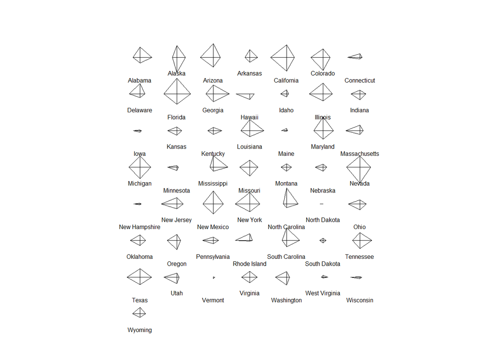

```r
stars(USArrests,cex=0.5)
```

눈에 띄는 군집이 형성되지 않음!

# 체르노프 얼굴그림

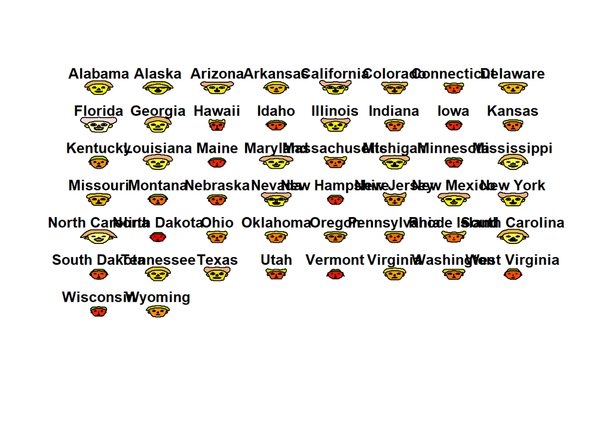

```
## effect of variables:
##  modified item       Var
##  "height of face   " "Murder"
##  "width of face    " "Assault"
##  "structure of face" "UrbanPop"
##  "height of mouth  " "Rape"
##  "width of mouth   " "Murder"
##  "smiling          " "Assault"
##  "height of eyes   " "UrbanPop"
##  "width of eyes    " "Rape"
##  "height of hair   " "Murder"
##  "width of hair   "  "Assault"
##  "style of hair   "  "UrbanPop"
##  "height of nose  "  "Rape"
##  "width of nose   "  "Murder"
##  "width of ear    "  "Assault"
##  "height of ear   "  "UrbanPop"
```

```r
library(aplpack)
faces(USArrests,cex=1.5)
```

육안으로 봤을때 군집화 할수 있을 정도로 식별됨!  
빨간얼굴 녹색머리 /갈색머리 노란얼굴 /노란머리 주황얼굴  
등 직관적으로 3개의 군집 관찰됨

# 시각화 하기 위한 ( 4 -> 3차원 축소)

```r
cor(USArrests) #상관계수분석
```

```
##              Murder   Assault   UrbanPop      Rape
## Murder   1.00000000 0.8018733 0.06957262 0.5635788
## Assault  0.80187331 1.0000000 0.25887170 0.6652412
## UrbanPop 0.06957262 0.2588717 1.00000000 0.4113412
## Rape     0.56357883 0.6652412 0.41134124 1.0000000
```

```r
ppccaa<-prcomp(USArrests,center=T,scale=T)
summary(ppccaa)
```

```
## Importance of components:
##                           PC1    PC2     PC3     PC4
## Standard deviation     1.5749 0.9949 0.59713 0.41645
## Proportion of Variance 0.6201 0.2474 0.08914 0.04336
## Cumulative Proportion  0.6201 0.8675 0.95664 1.00000
```

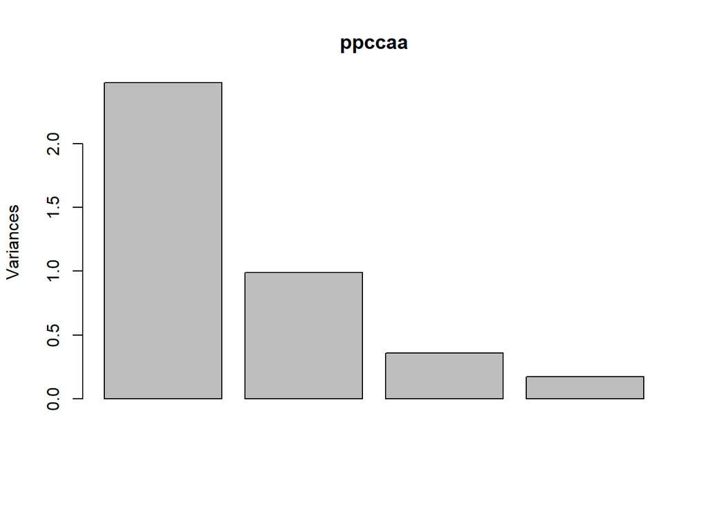

```r
plot(ppccaa)
```

시각화 한 것을 참고로 보면 세번째 주성분까지 사용해서 3차원 시각화!

# 3개의 변수로 바꾸기

```r
newppccaa<-as.matrix(USArrests)%*%ppccaa$rotation
newppccaa<-newppccaa[,1:3]
```

# 군집화 및 군집번호 열 추가

```r
gunzip<-kmeans(newppccaa,3)
newppccaa<-as.data.frame(newppccaa)
gun<-gunzip$cluster
gun<-as.data.frame(gun)
npa<-cbind(newppccaa,gun)
head(npa)
```

```
##                  PC1        PC2       PC3 gun
## Alabama    -172.3610  -4.285324 -72.37533   1
## Alaska     -196.2722   4.281646 -55.68900   1
## Arizona    -214.8984 -16.356340 -86.48977   1
## Arkansas   -140.0273  -7.505767 -56.90517   3
## California -213.1605 -30.570846 -78.27771   1
## Colorado   -165.9328 -32.901422 -55.23524   3
```

# 3차원 시각화

[figure not shown]

```r
library(ggplot2)
library(scatterplot3d)
shapes<-c(16,17,18)
shapes<-shapes[as.numeric(npa$gun)]
colors<-c("#999999", "#E69F00", "#56B4E9")
colors<-colors[as.numeric(npa$gun)]
scatterplot3d(npa,xlim=c(-250,0),ylim=c(-70,30),zlim=c(-100,0),angle=100,color=colors,pch=shapes,box=FALSE)
```

# 질문+공부할 것

1.scatterplot3d 위에 체르노프 얼굴 못그리나? (이미 군집화 해서 의미가 없을수도)  
2.scatterplot3d 위에 인덱스 이름 추가 못하나(도시 이름)  
3.가운데 정렬하면서 글씨 더 키우는법 ? (괄호센터랑 샾샾)  
4.Seatbelts 데이터 filter 함수 안먹힘(attach가 안됨)